HGG-oncohistones project [[source](https://github.com/fungenomics/HGG-oncohistones/blob/master/code/06-ACVR1.Rmd)]

# 06 - Effect of ACVR1

Selin Jessa []

12 September, 2022

# 1 Configuration

Configuration of project directory & analysis outputs:

**Show full config**

```r
source(here("rr_helpers.R"))

# Set up outputs
message("Document index: ", doc_id)
```

```
## Document index: 06
```

```r
# Specify where to save outputs
out        <- here("output", doc_id); dir.create(out, recursive = TRUE)
figout     <- here("figures", doc_id); dir.create(figout, recursive = TRUE)
cache      <- paste0(readLines(here("include/project_root.txt")), basename(here()), "/", doc_id, "/")
```

Outputs and figures will be saved at these paths, relative to project root:

```
## public/output/06
```

```
## public/figures/06
```

Setting a random seed:

```r
set.seed(100)
```

# 2 Overview

This document contains analyses to understand the dependency of ACVR1 in K27M and especially H3.1K27M gliomas, and to interrogate the changes that result from knocking-out ACVR1 using CRISPR in ACVR1 mutant HGG cell lines, as shown in Figure 6.

# 3 Libraries

```r
# Load libraries here
library(here)
library(tidyr)
library(dplyr)
library(ggrepel)
library(readr)
library(readxl)
library(glue)
library(tibble)
library(ggplot2)
library(purrr)
library(stringr)
library(cowplot)
library(fgsea)
library(icytobox)

source(here("include/style.R")) # contains palettes and custom style elements
source(here("code/functions/RNAseq.R"))
source(here("code/functions/ssGSEA.R"))
ggplot2::theme_set(theme_min())
```

# 4 ID genes ddPCR

ddPCR assay of ID gene expression.

```
## ...writing source data of ggplot to public/figures/06/ddpcr_id_genes-1.source_data.tsv
```

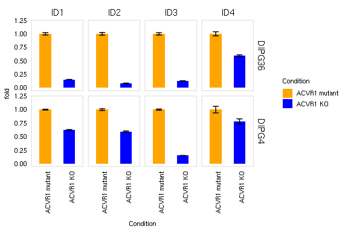

```r
# load data
ddpcr <- suppressMessages(read_tsv(here("data/experimental/2022-03-10-ddPCR_ID_genes_@mhulswit.txt")))

# barplot
ddpcr_tidy <- ddpcr %>%
  # remove xenografts
  filter(!grepl("[Xx]eno", Sample)) %>%
  gather(Stat, Value, matches("ID")) %>%
  separate(Stat, into = c("Gene", "Stat"), sep = "_") %>%
  spread(Stat, Value) %>%
  separate(Sample, into = c("Cell_line", "CRISPR"), sep = "_") %>%
  mutate(Condition = factor(Condition, levels = c("ACVR1 mutant", "ACVR1 KO")))

ddpcr_tidy %>%
  rr_ggplot(aes(x = Condition, y = fold), plot_num = 1) +
  geom_bar(aes(fill = Condition), stat = "identity", width = 0.5) +
  geom_errorbar(aes(ymin = fold - sd, ymax = fold + sd), width = 0.25) +
  scale_fill_manual(values = palette_acvr1) +
  facet_grid(Cell_line ~ Gene, scales = "free_x", space = "free", drop = TRUE) +
  ylim(c(0, 1.2)) +
  rotate_x()
```

<sub>[figure @ *public/figures/06/ddpcr_id_genes...*]</sub>

# 5 Clonogenesis

Data for clone formation assay for ACVR1 mutant and KO cell lines.

```
## ...writing source data of ggplot to public/figures/06/clonogenesis-1.source_data.tsv
```

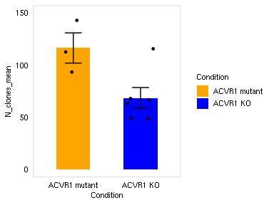

```r
# load data
clono <- suppressMessages(read_tsv(here("data/experimental/clonogenic_assay_DIPG36_@am.txt")))

# define standard error to quantify uncertainty around the mean
se <- function(x) sqrt(var(x)/length(x))

# tidy & plot
clono_tidy <- clono %>%
    set_colnames(c("ACVR1 mutant", "ACVR1 KO")) %>%
    gather(Condition, N_clones) %>%
    mutate(Condition = factor(Condition, levels = names(palette_acvr1))) %>%
    filter(!is.na(N_clones))

clono_tidy %>%
    group_by(Condition) %>%
    summarize(N_clones_mean = mean(N_clones),
              N_clones_se   = se(N_clones)) %>%
    rr_ggplot(aes(x = Condition, y = N_clones_mean), plot_num = 1) +
    geom_bar(aes(fill = Condition), stat = "identity", width = 0.5) +
    geom_errorbar(aes(ymin = N_clones_mean - N_clones_se, ymax = N_clones_mean + N_clones_se), width = 0.25) +
    geom_jitter(data = clono_tidy, aes(x = Condition, y = N_clones), width = 0.2, size = 1) +
    scale_fill_manual(values = palette_acvr1) +
    ylim(c(0, 150))
```

```r
t.test(clono$Parental, clono$`ACVR1 KO`, alternative = "two.sided", var.equal = TRUE)
```

```
##
##  Two Sample t-test
##
## data:  clono$Parental and clono$`ACVR1 KO`
## t = 2.7602, df = 7, p-value = 0.02809
## alternative hypothesis: true difference in means is not equal to 0
## 95 percent confidence interval:
##   6.855717 88.810950
## sample estimates:
## mean of x mean of y
## 116.50000  68.66667
```

<sub>[figure @ *public/figures/06/clonogenesis...*]</sub>

# 6 Doubling times

Doubling times of H3.1 and H3.3K27M cell lines.

```
## ...writing source data of ggplot to public/figures/06/doubling_H3.1_vs_H3.3-1.source_data.tsv
```

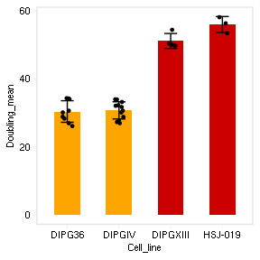

```r
# load data
doubling_H3.1_vs_H3.3 <- suppressMessages(read_tsv(here("data/experimental/doubling_time_H3.3_vs_H3.1_@am.txt")))

# tidy & plot
doubling_H3.1_vs_H3.3_tidy <- doubling_H3.1_vs_H3.3 %>%
    set_colnames(c("DIPGXIII", "HSJ-019", "DIPG36", "DIPGIV")) %>%
    gather(Cell_line, Doubling_time) %>%
    filter(!is.na(Doubling_time))

# use standard deviation to assesss variability of the measurements
doubling_H3.1_vs_H3.3_tidy %>%
    group_by(Cell_line) %>%
    summarize(Doubling_mean = mean(Doubling_time),
              Doubling_sd   = sd(Doubling_time)) %>%
    rr_ggplot(aes(x = Cell_line, y = Doubling_mean), plot_num = 1) +
    geom_bar(aes(fill = Cell_line), stat = "identity", width = 0.5) +
    geom_errorbar(aes(ymin = Doubling_mean - Doubling_sd, ymax = Doubling_mean + Doubling_sd), width = 0.25) +
    geom_jitter(data = doubling_H3.1_vs_H3.3_tidy, aes(x = Cell_line, y = Doubling_time), width = 0.1, size = 1) +
    scale_fill_manual(values = c("DIPG36" = "orange", "DIPGIV" = "orange", "DIPGXIII" = "red3", "HSJ-019" = "red3")) +
    no_legend()
```

<sub>[figure @ *public/figures/06/doubling_H3.1_vs_H3.3...*]</sub>

```
## ...writing source data of ggplot to public/figures/06/doubling_ACVR1-1.source_data.tsv
```

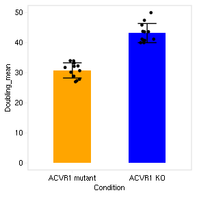

```r
# load data
doubling_ACVR1 <- suppressMessages(read_tsv(here("data/experimental/doubling_time_DIPGIV_ACVR1mut_vs_KO_@am.txt")))

# tidy & plot
doubling_ACVR1_tidy <- doubling_ACVR1 %>%
    set_colnames(c("ACVR1 mutant", "ACVR1 KO")) %>%
    gather(Condition, Doubling_time) %>%
    mutate(Condition = factor(Condition, levels = names(palette_acvr1))) %>%
    filter(!is.na(Condition))

doubling_ACVR1_tidy %>%
    group_by(Condition) %>%
    summarize(Doubling_mean = mean(Doubling_time),
              Doubling_sd   = sd(Doubling_time)) %>%
    rr_ggplot(aes(x = Condition, y = Doubling_mean), plot_num = 1) +
    geom_bar(aes(fill = Condition), stat = "identity", width = 0.5) +
    geom_errorbar(aes(ymin = Doubling_mean - Doubling_sd, ymax = Doubling_mean + Doubling_sd), width = 0.25) +
    geom_jitter(data = doubling_ACVR1_tidy, aes(x = Condition, y = Doubling_time), width = 0.1, size = 1) +
    scale_fill_manual(values = palette_acvr1) +
    no_legend() +
    ylim(c(0, 50))
```

<sub>[figure @ *public/figures/06/doubling_ACVR1...*]</sub>

# 7 Reproducibility

This document was last rendered on:

```
## 2022-09-12 15:23:43
```

The git repository and last commit:

```
## Local:    master /lustre06/project/6004736/sjessa/from_narval/HGG-oncohistones/public
## Remote:   master @ origin (git@github.com:fungenomics/HGG-oncohistones.git)
## Head:     [1a06382] 2022-09-08: Update comments, documentation, etc, based on lab feedback
```

The random seed was set with `set.seed(100)`

The R session info:

[output not shown]

The resources requested when this document was last rendered:

```
## #SBATCH --time=01:00:00
## #SBATCH --cpus-per-task=1
## #SBATCH --mem=20G
```

A project of the Kleinman Lab at McGill University, using the [rr](https://github.com/sjessa/rr/) reproducible research template.